# Freedman 2019 Tabla 3

## Calculos sobre la tabla 3 de Freedman et al 2019

```
Tabla 3, Freedman et al 2019
--  ------  -----  -----  ----  ----  -----  ----  -----  ----  -----  ----  ----
 1  1980N   N1316  31.46  0.04  CCHP  12.08  0.06  None   None  None   None  1306
 2  1981B   N4536  30.96  0.05  CCHP  11.64  0.04  30.91  0.05  11.62  0.12  1050
 3  1981D   N1316  31.46  0.04  CCHP  11.99  0.17  None   None  None   None  1306
 4  1989B   N3627  30.22  0.04  CCHP  11.16  0.07  None   None  None   None   689
 5  1990N   N4639  None   None  None  12.62  0.05  31.53  0.07  12.42  0.12  1050
 6  1994D   N4526  31.00  0.07  CCHP  11.76  0.04  None   None  None   None  1050
 7  1994ae  N3370  32.27  0.05  JL    12.94  0.05  32.07  0.05  12.92  0.12  1552
 8  1995al  N3021  32.22  0.05  JL    13.02  0.05  32.50  0.09  12.97  0.12  1886
 9  1998aq  N3982  None   None  None  12.46  0.05  31.74  0.07  12.24  0.12  1368
10  1998bu  N3368  30.31  0.04  CCHP  11.01  0.06  None   None  None   None   689
11  2001el  N1448  31.32  0.06  CCHP  12.3   0.04  31.31  0.04  12.20  0.12  1047
12  2002fk  N1309  32.50  0.07  JL    13.33  0.04  32.52  0.06  13.20  0.12  1864
13  2003du  U9391  None   None  None  13.47  0.09  32.92  0.06  13.47  0.11  2422
14  2005cf  N5917  None   None  None  12.96  0.07  32.26  0.10  13.01  0.12  2244
15  2006dd  N1316  31.46  0.04  CCHP  12.38  0.03  None   None  None   None  1306
16  2007af  N5584  31.82  0.10  JL    12.72  0.05  31.79  0.05  12.70  0.12  1983
17  2007on  N1404  31.42  0.05  CCHP  12.39  0.07  None   None  None   None  1306
18  2007sr  N4038  31.68  0.05  JL    12.3   0.15  31.29  0.11  12.24  0.11  1702
19  2009ig  N1015  None   None  None  13.29  0.05  32.50  0.08  13.46  0.12  2534
20  2011by  N3972  None   None  None  12.63  0.05  31.59  0.07  12.49  0.12  1368
21  2011fe  M101   29.08  0.04  CCHP   9.82  0.03  29.14  0.04  9.75   0.12   455
22  2011iv  N1404  31.42  0.05  CCHP  12.03  0.06  None   None  None   None  1306
23  2012cg  N4424  31.00  0.06  CCHP  11.72  0.06  31.08  0.29  11.55  0.11  1050
24  2012fr  N1365  31.36  0.05  CCHP  12.09  0.03  31.31  0.06  11.92  0.12  1302
25  2012ht  N3447  None   None  None  12.66  0.12  31.91  0.04  12.70  0.12  1447
26  2013dy  N7250  None   None  None  12.23  0.07  31.50  0.08  12.31  0.12  1410
27  2015F   N2442  None   None  None  12.4   0.03  31.51  0.05  12.28  0.14  1271
--  ------  -----  -----  ----  ----  -----  ----  -----  ----  -----  ----  ----
```

### Correccion R16->R19

Agregamos la correccion global a los modulos de distancia de Cefeidas, para llevar R16 a R19, esto es sumarles $-0.029$ mag.

```
Correccion Global de -0.029 mag
    Host      DMceph    DMcephCorr
--  ------  --------  ------------
 2  N4536      30.91        30.881
 5  N4639      31.53        31.501
 7  N3370      32.07        32.041
 8  N3021      32.5         32.471
 9  N3982      31.74        31.711
11  N1448      31.31        31.281
12  N1309      32.52        32.491
13  U9391      32.92        32.891
14  N5917      32.26        32.231
16  N5584      31.79        31.761
18  N4038      31.29        31.261
19  N1015      32.5         32.471
20  N3972      31.59        31.561
21  M101       29.14        29.111
23  N4424      31.08        31.051
24  N1365      31.31        31.281
25  N3447      31.91        31.881
26  N7250      31.5         31.471
27  N2442      31.51        31.481
```

### Separacion por distancia (TRGB/Ceph) y Fotometria de SN(CSP/SuperCal)

```
CSP+TRGB
    SN      Host      DMtrgb    eDMtrgb    CSPpeak    eCSPpeak
--  ------  ------  --------  ---------  ---------  ----------
 1  1980N   N1316      31.46       0.04      12.08        0.06
 2  1981B   N4536      30.96       0.05      11.64        0.04
 3  1981D   N1316      31.46       0.04      11.99        0.17
 4  1989B   N3627      30.22       0.04      11.16        0.07
 6  1994D   N4526      31          0.07      11.76        0.04
 7  1994ae  N3370      32.27       0.05      12.94        0.05
 8  1995al  N3021      32.22       0.05      13.02        0.05
10  1998bu  N3368      30.31       0.04      11.01        0.06
11  2001el  N1448      31.32       0.06      12.3         0.04
12  2002fk  N1309      32.5        0.07      13.33        0.04
15  2006dd  N1316      31.46       0.04      12.38        0.03
16  2007af  N5584      31.82       0.1       12.72        0.05
```

[output cut: 66 more lines]

### Cálculo de $M_B$

Ahora definimos una funcion que calculará 2 numeros en todas las tablas:

$ Promedio\,Pesado = \frac{\sum{w_i\,(m_i-\mu_i)}}{\sum{w_i}} $

$ Error^{-1} = \sqrt{\frac{1}{\sum{w_i}}}$

donde $w_i = \frac{1}{\sigma_i^2}$ , y $\sigma$ viene de la cuadratura de los errores:

$\sigma^2 = \sigma_{SN}^2 + \sigma_{TRGB/Ceph}^2$

Esta es la tabla con los resultados, y los histogramas de cada caso:

| SN Phot | TRGB | Ceph | eTRGB | eCeph | diff | diff_sigmas |
| --- | --- | --- | --- | --- | --- | --- |
| CSP | -19.223 | -19.152 | 0.017 | 0.018 | -0.072 | 2.858 |
| SuperCal | -19.325 | -19.221 | 0.042 | 0.032 | -0.104 | 1.976 |

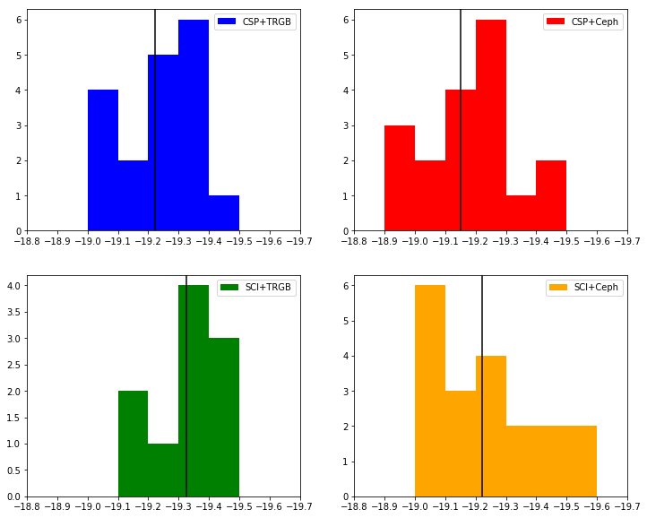

### Host comunes

Ahora repetimos el calculo con los host que tienen ambos MD (Cefeidas y TRGB)

```
--  ------  -----  -----  ----  ----  -----  ----  -----  ----  -----  ----  ----  ------
 2  1981B   N4536  30.96  0.05  CCHP  11.64  0.04  30.91  0.05  11.62  0.12  1050  30.881
 7  1994ae  N3370  32.27  0.05  JL    12.94  0.05  32.07  0.05  12.92  0.12  1552  32.041
 8  1995al  N3021  32.22  0.05  JL    13.02  0.05  32.5   0.09  12.97  0.12  1886  32.471
11  2001el  N1448  31.32  0.06  CCHP  12.3   0.04  31.31  0.04  12.2   0.12  1047  31.281
12  2002fk  N1309  32.5   0.07  JL    13.33  0.04  32.52  0.06  13.2   0.12  1864  32.491
16  2007af  N5584  31.82  0.1   JL    12.72  0.05  31.79  0.05  12.7   0.12  1983  31.761
18  2007sr  N4038  31.68  0.05  JL    12.3   0.15  31.29  0.11  12.24  0.11  1702  31.261
21  2011fe  M101   29.08  0.04  CCHP   9.82  0.03  29.14  0.04   9.75  0.12   455  29.111
23  2012cg  N4424  31     0.06  CCHP  11.72  0.06  31.08  0.29  11.55  0.11  1050  31.051
24  2012fr  N1365  31.36  0.05  CCHP  12.09  0.03  31.31  0.06  11.92  0.12  1302  31.281
--  ------  -----  -----  ----  ----  -----  ----  -----  ----  -----  ----  ----  ------
```

Los subsets serán los siguientes:

```
CSP+TRGB(comm)
--  ------  -----  -----  ----  -----  ----
 2  1981B   N4536  30.96  0.05  11.64  0.04
 7  1994ae  N3370  32.27  0.05  12.94  0.05
 8  1995al  N3021  32.22  0.05  13.02  0.05
11  2001el  N1448  31.32  0.06  12.3   0.04
12  2002fk  N1309  32.5   0.07  13.33  0.04
16  2007af  N5584  31.82  0.1   12.72  0.05
18  2007sr  N4038  31.68  0.05  12.3   0.15
21  2011fe  M101   29.08  0.04   9.82  0.03
23  2012cg  N4424  31     0.06  11.72  0.06
24  2012fr  N1365  31.36  0.05  12.09  0.03
--  ------  -----  -----  ----  -----  ----

CSP+Ceph(comm)
```

[output cut: 40 more lines]

Y aqui la tabla con resultados y los histogramas:

| SN Phot | TRGB | Ceph | eTRGB | eCeph | diff | diff_sigmas |
| --- | --- | --- | --- | --- | --- | --- |
| CSP | -19.237 | -19.166 | 0.023 | 0.023 | -0.071 | 2.188 |
| SuperCal | -19.325 | -19.232 | 0.042 | 0.044 | -0.092 | 1.522 |

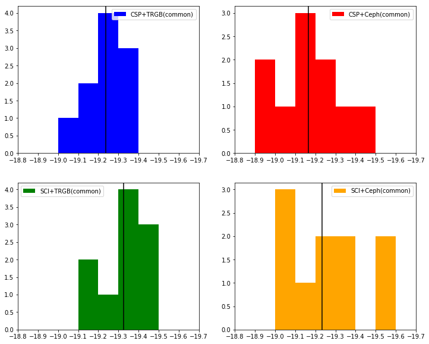

### JL & CCHP.

Ahora nos interesa un subconjunto de estos ultimos. Aquellos cuya distancia TRGB viene de JL or CCHP.

```
JL
--  ------  -----  -----  ----  --  -----  ----  -----  ----  -----  ----  ----  ------
 7  1994ae  N3370  32.27  0.05  JL  12.94  0.05  32.07  0.05  12.92  0.12  1552  32.041
 8  1995al  N3021  32.22  0.05  JL  13.02  0.05  32.5   0.09  12.97  0.12  1886  32.471
12  2002fk  N1309  32.5   0.07  JL  13.33  0.04  32.52  0.06  13.2   0.12  1864  32.491
16  2007af  N5584  31.82  0.1   JL  12.72  0.05  31.79  0.05  12.7   0.12  1983  31.761
18  2007sr  N4038  31.68  0.05  JL  12.3   0.15  31.29  0.11  12.24  0.11  1702  31.261
--  ------  -----  -----  ----  --  -----  ----  -----  ----  -----  ----  ----  ------
```

```
CCHP
--  ------  -----  -----  ----  ----  -----  ----  -----  ----  -----  ----  ----  ------
 2  1981B   N4536  30.96  0.05  CCHP  11.64  0.04  30.91  0.05  11.62  0.12  1050  30.881
11  2001el  N1448  31.32  0.06  CCHP  12.3   0.04  31.31  0.04  12.2   0.12  1047  31.281
21  2011fe  M101   29.08  0.04  CCHP   9.82  0.03  29.14  0.04   9.75  0.12   455  29.111
23  2012cg  N4424  31     0.06  CCHP  11.72  0.06  31.08  0.29  11.55  0.11  1050  31.051
24  2012fr  N1365  31.36  0.05  CCHP  12.09  0.03  31.31  0.06  11.92  0.12  1302  31.281
--  ------  -----  -----  ----  ----  -----  ----  -----  ----  -----  ----  ----  ------
```

Tabla e Histogramas

| Subset | SN Phot | TRGB | eTRGB |
| --- | --- | --- | --- |
| JL | CSP | -19.231 | 0.039 |
| JL | SuperCal | -19.308 | 0.06 |
| CCHP | CSP | -19.24 | 0.028 |
| CCHP | SuperCal | -19.34 | 0.058 |

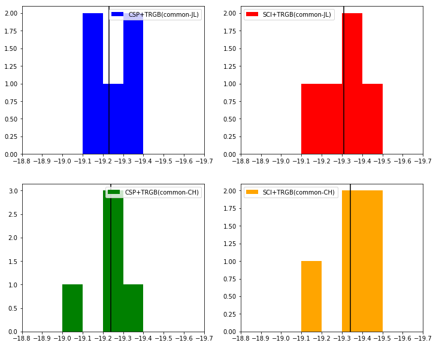

### Hosts con una sola distancia

Ahora buscamos aquellas que solo tienen un modulo de distancia (TRGB o Cefeida)

```
CSP+trgb
--  ------  -----  -----  ----  -----  ----
 1  1980N   N1316  31.46  0.04  12.08  0.06
 3  1981D   N1316  31.46  0.04  11.99  0.17
 4  1989B   N3627  30.22  0.04  11.16  0.07
 6  1994D   N4526  31     0.07  11.76  0.04
10  1998bu  N3368  30.31  0.04  11.01  0.06
15  2006dd  N1316  31.46  0.04  12.38  0.03
17  2007on  N1404  31.42  0.05  12.39  0.07
22  2011iv  N1404  31.42  0.05  12.03  0.06
--  ------  -----  -----  ----  -----  ----

CSP+ceph
--  ------  -----  ------  ----  -----  ----
 5  1990N   N4639  31.501  0.07  12.62  0.05
```

[output cut: 22 more lines]

Tabla e histogramas:

| SN Phot | TRGB | Ceph | eTRGB | eCeph |
| --- | --- | --- | --- | --- |
| CSP | -19.2053 | -19.127 | 0.0264984 | 0.03 |
| SuperCal | ---- | -19.209 | ---- | 0.046 |

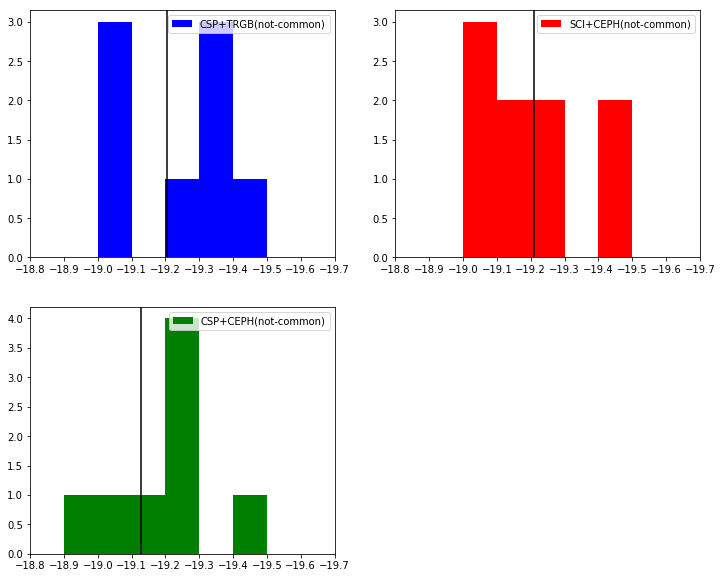

### Subsets M5, M4 & M3

Por último, algunos subsets de CSP+TRGB. M5, M4 y M3 que vienen de quitar algunos objetos.

```
CSP+TRGB(M5)
    SN      Host      DMtrgb    eDMtrgb    CSPpeak    eCSPpeak
--  ------  ------  --------  ---------  ---------  ----------
 2  1981B   N4536      30.96       0.05      11.64        0.04
 4  1989B   N3627      30.22       0.04      11.16        0.07
 6  1994D   N4526      31          0.07      11.76        0.04
 7  1994ae  N3370      32.27       0.05      12.94        0.05
 8  1995al  N3021      32.22       0.05      13.02        0.05
10  1998bu  N3368      30.31       0.04      11.01        0.06
11  2001el  N1448      31.32       0.06      12.3         0.04
12  2002fk  N1309      32.5        0.07      13.33        0.04
16  2007af  N5584      31.82       0.1       12.72        0.05
18  2007sr  N4038      31.68       0.05      12.3         0.15
21  2011fe  M101       29.08       0.04       9.82        0.03
23  2012cg  N4424      31          0.06      11.72        0.06
```

[output cut: 38 more lines]

Tabla e histogramas:

| SN Phot | TRGB | eTRGB |
| --- | --- | --- |
| M5 | -19.231 | 0.02 |
| M4 | -19.22 | 0.02 |
| M3 | -19.201 | 0.018 |

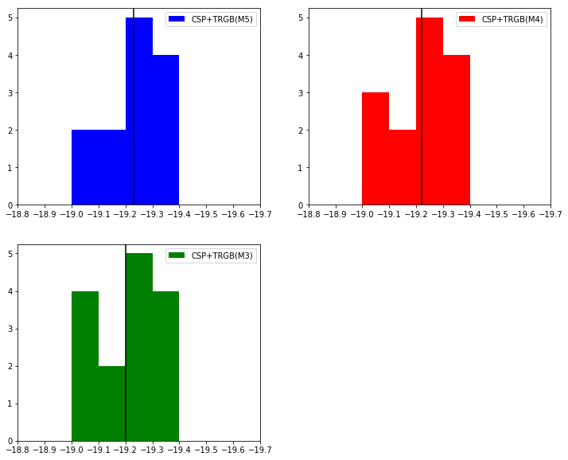

### Figura 9 de Freedman et al

Aqui se replica la figura 9.

[figure not shown]

[figure not shown]

## Calculo de Ho

Para este calculo tomaré la siguiente expresion como invariante:

$5\, log(H_0) - M_B = C_0$

Esto implica que el cambio en $H_0$ correspondera a un equivalente cambio en $M_B$. Como en la siguiente expresion:

$\frac{\delta H_0}{H_0} =\delta M_B \frac{ln (10)}{5}$

de lo cual, el valor perturbado de $H_0$ sera:

$H_0' = H_0 (1 - \frac{ln(10)}{5} (M_{B,0}-M_B'))$

Para el caso de TRGB+CSP, $H_0$ y $M_{B,0}$ se toman de Freedman 2019 (Tabla 5), con los valores:

$H_0= 69.67 \quad\quad M_{B,0}=-19.14$

los resultados son:

| Subset | M_B | eM_B | H_0 |
| --- | --- | --- | --- |
| All | -19.223 | 0.017 | 66.998 |
| Common | -19.237 | 0.023 | 66.574 |
| Not-Common | -19.205 | 0.026 | 67.576 |
| M5 | -19.231 | 0.02 | 66.763 |
| M4 | -19.22 | 0.02 | 67.1 |
| M3 | -19.201 | 0.018 | 67.704 |

Para el caso de Ceph+CSP, los valores de Burns et al 2018 son:

$H_0= 72.67 \quad\quad M_{B,0}=-19.162$

y los valores resultantes son:

| Subset | M_B | eM_B | H_0 |
| --- | --- | --- | --- |
| All | -19.152 | 0.018 | 73.015 |
| Common | -19.166 | 0.023 | 72.538 |
| Not-Common | -19.127 | 0.03 | 73.832 |